# 1_Follow_up

2025-04-22

In this code I will directly address the points for follow-up that were denoted in the previous progress report.

The points are: 1. Confirm the genes of interest using the selection and filtering methods discussed. 2. Compare the LUSC genes of interest with the LUAD genes of interest. 3. Compare former vs. never smoker tumor methylation as another point of interest for the analysis. 4. Explore the statistical significance of overlapping genes and give a detailed report of the results and their implications. 5. Once we have confirmed that the lists of genes of interest are finalized, I can use the datasets listed in comment 8 to make further comparisons and refine the hypothesis.

Addressing the points:

# 1. Confirm the genes of interest using the selection and filtering methods discussed.

This is up to the committee. When I change the lists of genes of interest it will affect the checks after this point.

# 2. Compare the LUSC genes of interest with the LUAD genes of interest.

## Read in the genes of interest

```r
library(dplyr)
## These are the genes of interest I have defined as of 2025/05/16

# LUAD
LUAD_A1_TE <- read.table("../../2_Outputs/4_Linked_genes/LUAD_A1_TE_20250514.txt")
LUAD_A1_TE_A2 <- read.table("../../2_Outputs/4_Linked_genes/LUAD_A1_TE_A2_20250514.txt")
LUAD_A1_TE_A2_TM <- read.table("../../2_Outputs/4_Linked_genes/LUAD_A1_TE_A2_TM_20250610.txt")

# LUSC
LUSC_A1_TE <- read.table("../../2_Outputs/4_Linked_genes/LUSC_A1_TE_20250514.txt")
LUSC_A1_TE_A2 <- read.table("../../2_Outputs/4_Linked_genes/LUSC_A1_TE_A2_20250514.txt")
LUSC_A1_TE_A2_TM <- read.table("../../2_Outputs/4_Linked_genes/LUSC_A1_TE_A2_TM_20250610.txt")
```

## Compare the gene lists to each other with euler/“venn” diagrams

```r
library(eulerr)
## First just checking upregulated vs downregulated genes in everything

nrow(LUAD_A1_TE[sign(LUAD_A1_TE$log2FC_A1)=="1",])
```

```
## [1] 139
```

```r
nrow(LUAD_A1_TE[sign(LUAD_A1_TE$log2FC_A1)=="-1",])
```

```
## [1] 141
```

```r
nrow(LUAD_A1_TE_A2[sign(LUAD_A1_TE_A2$log2FC_A1)=="1",])
```

```
## [1] 9
```

```r
nrow(LUAD_A1_TE_A2[sign(LUAD_A1_TE_A2$log2FC_A1)=="-1",])
```

```
## [1] 9
```

```r
nrow(LUSC_A1_TE[sign(LUSC_A1_TE$log2FC_A1)=="1",])
```

```
## [1] 141
```

```r
nrow(LUSC_A1_TE[sign(LUSC_A1_TE$log2FC_A1)=="-1",])
```

```
## [1] 190
```

```r
nrow(LUSC_A1_TE_A2[sign(LUSC_A1_TE_A2$log2FC_A1)=="1",])
```

```
## [1] 7
```

```r
nrow(LUSC_A1_TE_A2[sign(LUSC_A1_TE_A2$log2FC_A1)=="-1",])
```

```
## [1] 12
```

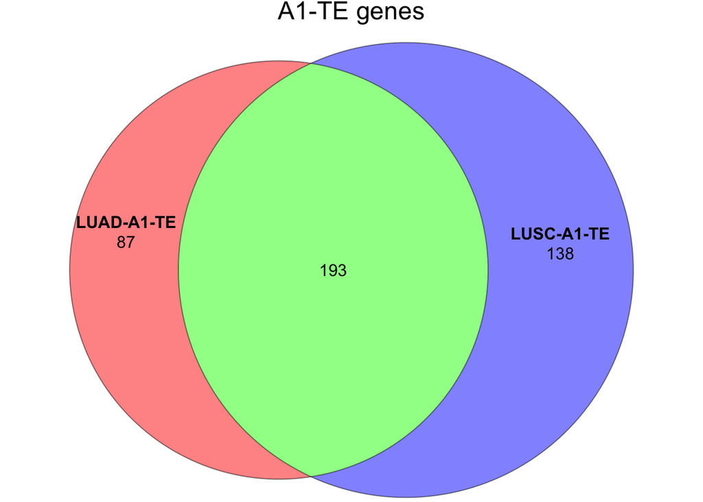

```r
### First just comparing all gene names

# A1_TE gene comparison between LUAD and LUSC
A1_TE_gene_sets <- euler(list("LUAD-A1-TE" = unique(LUAD_A1_TE$Gene), "LUSC-A1-TE" = unique(LUSC_A1_TE$Gene)))

plot(main = "A1-TE genes",
     A1_TE_gene_sets,
     quantities = TRUE,  # Show counts in regions
     fills = c("red", "blue", "green"),
     alpha = 0.5,
     edges = TRUE)
```

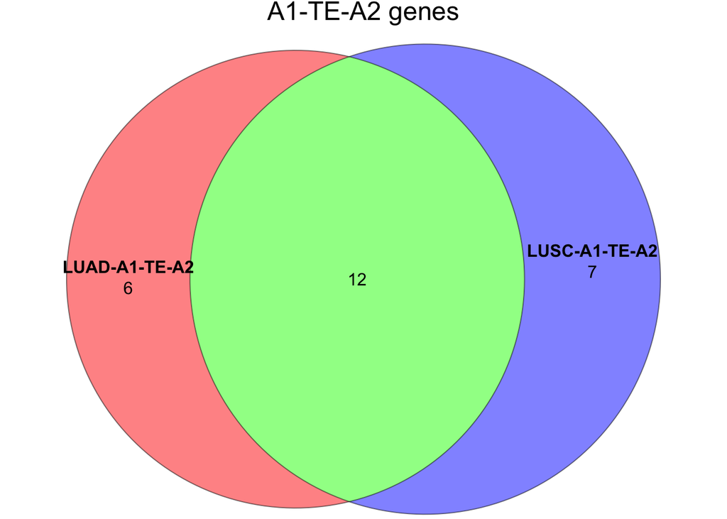

```r
# A1_TE_A2 comparison between LUAD and LUSC

A1_TE_A2_gene_sets <- euler(list("LUAD-A1-TE-A2" = unique(LUAD_A1_TE_A2$Gene), "LUSC-A1-TE-A2" = unique(LUSC_A1_TE_A2$Gene)))

plot(main = "A1-TE-A2 genes",
     A1_TE_A2_gene_sets,
     quantities = TRUE,  # Show counts in regions
     fills = c("red", "blue", "green"),
     alpha = 0.5,
     edges = TRUE)
```

## Checking signs

```r
## Now checking whether sign is the same

#Narrowing it down to the shared genes
LUAD_LUSC_A1_TE_shared <- LUAD_A1_TE %>%
  inner_join(., LUSC_A1_TE, by = "Gene", suffix = c("_LUAD", "_LUSC"))

#Make a column to state sign status
LUAD_LUSC_A1_TE_shared$sign_LUAD <- sign(LUAD_LUSC_A1_TE_shared$log2FC_A1_LUAD)
LUAD_LUSC_A1_TE_shared$sign_LUSC <- sign(LUAD_LUSC_A1_TE_shared$log2FC_A1_LUSC)
LUAD_LUSC_A1_TE_shared$signs_match <- LUAD_LUSC_A1_TE_shared$sign_LUAD == LUAD_LUSC_A1_TE_shared$sign_LUSC
## All signs match

# Checking how many up/down-regulated in shared genes
nrow(LUAD_LUSC_A1_TE_shared[LUAD_LUSC_A1_TE_shared$sign_LUAD=="1",])
```

```
## [1] 76
```

```r
nrow(LUAD_LUSC_A1_TE_shared[LUAD_LUSC_A1_TE_shared$sign_LUAD=="-1",])
```

```
## [1] 117
```

```r
## Checking the unique genes
LUAD_A1_TE_unique <- LUAD_A1_TE[!(LUAD_A1_TE$Gene %in% LUSC_A1_TE$Gene),]
nrow(LUAD_A1_TE_unique[sign(LUAD_A1_TE_unique$log2FC_A1)=="1",])
```

```
## [1] 63
```

```r
nrow(LUAD_A1_TE_unique[sign(LUAD_A1_TE_unique$log2FC_A1)=="-1",])
```

```
## [1] 24
```

```r
LUSC_A1_TE_unique <- LUSC_A1_TE[!(LUSC_A1_TE$Gene %in% LUSC_A1_TE$Gene),]
nrow(LUSC_A1_TE_unique[sign(LUSC_A1_TE_unique$log2FC_A1)=="1",])
```

```
## [1] 0
```

```r
nrow(LUSC_A1_TE_unique[sign(LUSC_A1_TE_unique$log2FC_A1)=="-1",])
```

```
## [1] 0
```

```r
## Checking signs for the methylatgion genes
nrow(LUAD_A1_TE_A2_TM[sign(LUAD_A1_TE_A2_TM$log2FC_TM)=="1",])
```

```
## [1] 1
```

```r
nrow(LUSC_A1_TE_A2_TM[sign(LUSC_A1_TE_A2_TM$log2FC_TM)=="1",])
```

```
## [1] 3
```

## Take a look at pathways for the genes that are common or different here

```r
library(dplyr)

## A1-TE

# Shared between LUAD_A1_TE and LUSC_A1_TE
A1_TE_shared <- intersect(LUAD_A1_TE$Gene, LUSC_A1_TE$Gene)
length(A1_TE_shared)
```

```
## [1] 193
```

```r
# Unique to LUAD_A1_TE
LUAD_A1_TE_unique <- setdiff(LUAD_A1_TE$Gene, LUSC_A1_TE$Gene)
length(LUAD_A1_TE_unique)
```

```
## [1] 87
```

```r
# Unique to LUSC_A1_TE
LUSC_A1_TE_unique <- setdiff(LUSC_A1_TE$Gene, LUAD_A1_TE$Gene)
length(LUSC_A1_TE_unique)
```

```
## [1] 138
```

```r
## A1-TE-A2

# Shared between LUAD_A1_TE_A2 and LUSC_A1_TE_A2
A1_TE_A2_shared <- intersect(LUAD_A1_TE_A2$Gene, LUSC_A1_TE_A2$Gene)
length(A1_TE_A2_shared)
```

```
## [1] 12
```

```r
# Unique to LUAD_A1_TE_A2
LUAD_A1_TE_A2_unique <- setdiff(LUAD_A1_TE_A2$Gene, LUSC_A1_TE_A2$Gene)
length(LUAD_A1_TE_A2_unique)
```

```
## [1] 6
```

```r
# Unique to LUSC_A1_TE_A2
LUSC_A1_TE_A2_unique <- setdiff(LUSC_A1_TE_A2$Gene, LUAD_A1_TE_A2$Gene)
length(LUSC_A1_TE_A2_unique)
```

```
## [1] 7
```

## Comparing the genes resulting from the SMD meta analysis (3.2, 3.3)

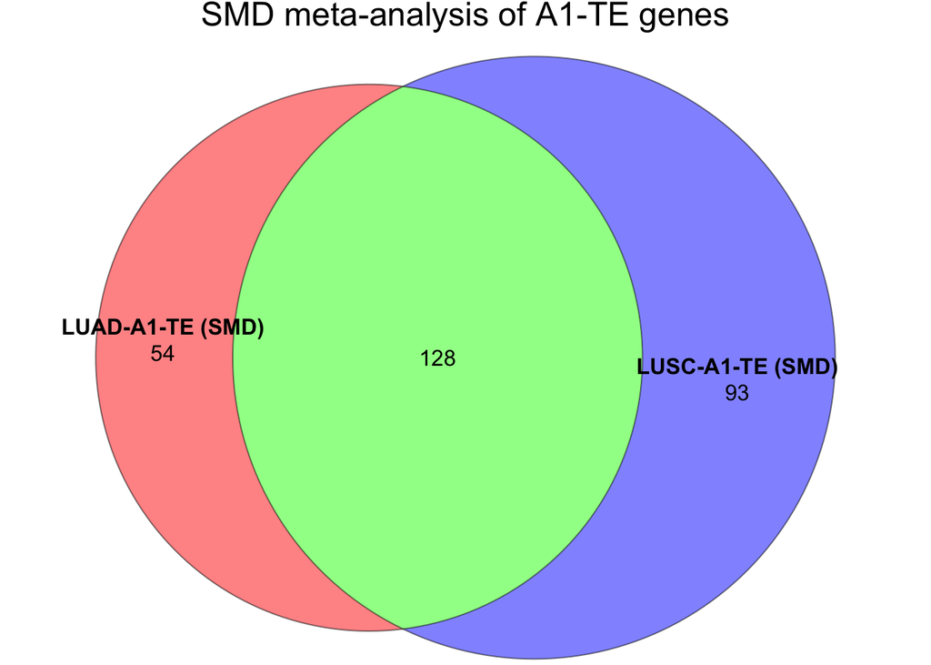

```r
library(eulerr)

## Read in the gene lists
LUAD_A1_TE_SMD_summary_overall <- read.table("../../2_Outputs/6_Meta_analysis/LUAD_A1_TE_SMD_summary_overall_20250611.txt")
LUSC_A1_TE_SMD_summary_overall <- read.table("../../2_Outputs/6_Meta_analysis/LUSC_A1_TE_SMD_summary_overall_20250611.txt")

# Filter for FDR
LUAD_A1_TE_SMD_summary_overall_filter <- LUAD_A1_TE_SMD_summary_overall[LUAD_A1_TE_SMD_summary_overall$FDR_random<=0.05,]
LUSC_A1_TE_SMD_summary_overall_filter <- LUSC_A1_TE_SMD_summary_overall[LUSC_A1_TE_SMD_summary_overall$FDR_random<=0.05,]

SMD_meta_analysis_genes <- euler(list("LUAD-A1-TE (SMD)" = unique(LUAD_A1_TE_SMD_summary_overall_filter$gene), "LUSC-A1-TE (SMD)" = unique(LUSC_A1_TE_SMD_summary_overall_filter$gene)))

plot(main = "SMD meta-analysis of A1-TE genes",
     SMD_meta_analysis_genes,
     quantities = TRUE,  # Show counts in regions
     fills = c("red", "blue", "green"),
     alpha = 0.5,
     edges = TRUE)
```

```r
# Shared between LUAD and LUSC meta analysis genes
SMD_meta_shared <- intersect(LUAD_A1_TE_SMD_summary_overall_filter$gene, LUSC_A1_TE_SMD_summary_overall_filter$gene)
# Pathways shared: https://maayanlab.cloud/Enrichr/enrich?dataset=81c21d6319be95a21dea10e8df76ec5f

# Unique to LUAD
LUAD_SMD_meta_unique <- setdiff(LUAD_A1_TE_SMD_summary_overall_filter$gene, LUSC_A1_TE_SMD_summary_overall_filter$gene)
# PAthways for LUAD: https://maayanlab.cloud/Enrichr/enrich?dataset=052df690b890326b1ce8b8247886a780

# Unique to LUSC
LUSC_SMD_meta_unique <- setdiff(LUSC_A1_TE_SMD_summary_overall_filter$gene, LUAD_A1_TE_SMD_summary_overall_filter$gene)
# Pathways for LUSC: https://maayanlab.cloud/Enrichr/enrich?dataset=873b696ac486eecf36b86b451cbe6159
```

# 3. Compare former vs. never smoker tumor methylation as another point of interest for the analysis.

I could see doing this in two different ways:

3.1. Take the A1-TE-A2 genes and check how well they can stratify former from never smokers in the TCGA methylation data using either a PCA or hierarchical clustering

3.2. Do differential analysis of former vs. never smokers in tumors and compare the gene list to the A1-TE-A2 list.

### LUAD

#### Read in the clinical data

```r
library(TCGAbiolinks)
library(SummarizedExperiment)
library(dplyr)

## Read in TCGA-LUSC clinical data
query_clinical <- GDCquery(
  project = "TCGA-LUAD",
  data.category = "Clinical",
  data.type = "Clinical Supplement"
)
```

[output not shown]

```
## Genome of reference: hg38
```

[output not shown]

```
## ooo Project: TCGA-LUAD
```

[output not shown]

```
## ooo By data.type
```

[output not shown]

```
## ooo Checking if there are duplicated cases
```

[output not shown]

```
## o Preparing output
```

```r
# Check the available files
query_clinical$results[[1]] %>% head()
```

```
##                                     id data_format        cases access
## 1 d3bc0e7d-52c8-4640-977f-c983dd256591     BCR XML TCGA-78-7166   open
## 2 3f37c9f9-1ef8-4735-a36f-42058f691678 BCR OMF XML TCGA-78-7166   open
## 3 d012dbe2-4758-4d33-9dbe-c1844da5cfad BCR OMF XML TCGA-38-4631   open
## 4 897b9e78-9a86-4d48-8aed-62b5af4e853d BCR OMF XML TCGA-55-8511   open
## 5 2486c117-e1ec-4c6f-a095-51a217dbd660     BCR XML TCGA-50-6597   open
## 6 649568d4-721a-47ce-848b-a276d15036f7 BCR OMF XML TCGA-50-6597   open
##                                           file_name
## 1 nationwidechildrens.org_clinical.TCGA-78-7166.xml
## 2      nationwidechildrens.org_omf.TCGA-78-7166.xml
## 3      nationwidechildrens.org_omf.TCGA-38-4631.xml
## 4      nationwidechildrens.org_omf.TCGA-55-8511.xml
## 5 nationwidechildrens.org_clinical.TCGA-50-6597.xml
## 6      nationwidechildrens.org_omf.TCGA-50-6597.xml
##                                        submitter_id data_category
```

[output cut: 34 more lines]

```r
## I see that some are not BCR XML files, so I will try to remove these
query_clinical$results[[1]] <- query_clinical$results[[1]] %>%
  filter(data_format == "BCR XML")

## Download data
GDCdownload(query_clinical,files.per.chunk = 1)
```

```
## Of the 522 files for download 522 already exist.
```

```
## All samples have been already downloaded
```

```r
clinical_data <- GDCprepare_clinic(query_clinical, clinical.info = "patient")
```

[output not shown]

```
## To get the following information please change the clinical.info argument
```

```
## => new_tumor_events: new_tumor_event
## => drugs: drug
## => follow_ups: follow_up
## => radiations: radiation
```

```
## Parsing follow up version: follow_up_v1.0
```

[output not shown]

```
## Adding stage event information
```

[output not shown]

```
## Updating days_to_last_followup and vital_status from follow_up information using last entry
## Parsing follow up version: follow_up_v1.0
```

[output not shown]

```r
## Sort by tobacco smoking history
clinical_data_smoking_history <- clinical_data %>%
  arrange(., tobacco_smoking_history) %>%
  select(bcr_patient_barcode, tobacco_smoking_history)
```

### Read in the methylation data and arrange by smoking history

```r
# Get the patient barcodes in a form that can be used to filter the tumor samples
clinical_data_smoking_history_sample_barcodes <- clinical_data_smoking_history %>%
  mutate(bcr_patient_barcode = bcr_patient_barcode %>%
    gsub("$", ".01", .) %>%
    gsub("-", "\\.", .)
  )

## Read in the data for TCGA-LUAD methylation
LUAD_methylation_hm450_tumor <- read.table("../3_TCGA_data/TCGA_LUAD/data_methylation_hm450_LUAD.txt", header=TRUE, fill=TRUE)

# Get the barcodes existing in rownames of the sample info
clinical_data_smoking_history_sample_barcodes_methyl <- clinical_data_smoking_history_sample_barcodes[clinical_data_smoking_history_sample_barcodes$bcr_patient_barcode %in% colnames(LUAD_methylation_hm450_tumor),]
```

## Deal with duplicate genes and make them the rownames of the methylation table

```r
### 3.2.2 Handling duplicate genes
library(dplyr)

# Step 1: Identify rows with duplicate Gene values
duplicates <- LUAD_methylation_hm450_tumor %>%
  group_by(Hugo_Symbol) %>%
  filter(n() > 1)

# Step 2: Remove the row with the smallest row sum for each duplicate gene
rows_to_remove <- duplicates %>%
  rowwise() %>%
  mutate(row_sum = sum(c_across(where(is.numeric)))) %>%  # Compute row sum for numeric columns
  group_by(Hugo_Symbol) %>%
  slice_min(row_sum, with_ties = FALSE) %>%  # Select the row with the smallest sum
  ungroup()

# Step 3: Remove these rows from the original dataframe
LUAD_methylation_hm450_tumor <- anti_join(LUAD_methylation_hm450_tumor, rows_to_remove, by = colnames(LUAD_methylation_hm450_tumor))

# Now make the gene names into row names
rownames(LUAD_methylation_hm450_tumor) <- LUAD_methylation_hm450_tumor$Hugo_Symbol

# Remove the ID columns
LUAD_methylation_hm450_tumor$Hugo_Symbol <- NULL
LUAD_methylation_hm450_tumor$Entrez_Gene_Id <- NULL
```

## PCA of the LUAD methylation data using A1-TE-A2 genes and coloring by smoking status (filtering out 5 (FS of unspecified TSQ duration))

```r
library(limma)
```

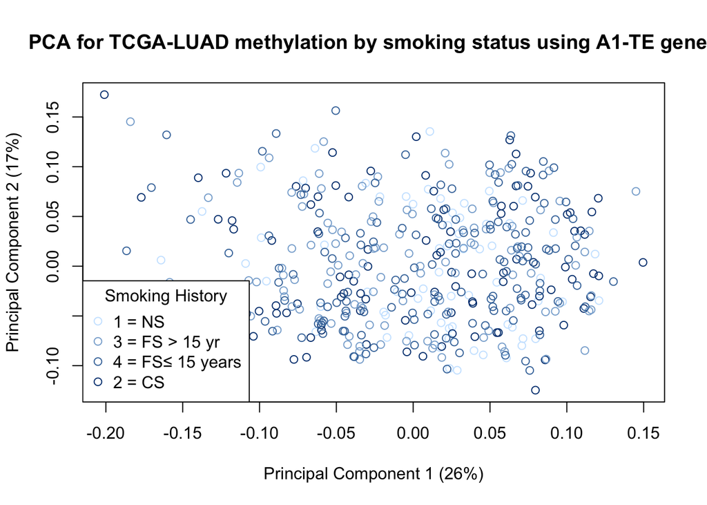

```r
## Setting up the dataframe

# Order the dataframe by smoking status
LUAD_methylation_hm450_tumor_sstat <- LUAD_methylation_hm450_tumor %>%
  select(clinical_data_smoking_history_sample_barcodes_methyl$bcr_patient_barcode)

# Filter to just LUAD-A1-TE-A2 genes
LUAD_methylation_hm450_tumor_sstat_A1_TE <- LUAD_methylation_hm450_tumor_sstat %>%
  filter(rownames(.) %in% LUAD_A1_TE_A2$Gene)


## Plot a PCA based on A1-TE genes, using color to represent smoking status

# Smoking status
smoking_status <- clinical_data_smoking_history_sample_barcodes_methyl$tobacco_smoking_history

# Only keep samples with status 1, 2, 3, or 4
valid_idx <- smoking_status %in% c(1, 2, 3, 4)
smoking_status_filtered <- smoking_status[valid_idx]

# Define custom order for color darkness
status_order <- c(1, 3, 4, 2)  # lightest to darkest

# Create color ramp
blues <- colorRampPalette(c("#cce6ff", "#004080"))(length(status_order))

# Create a named vector mapping statuses to colors
status_color_map <- setNames(blues, status_order)

# Assign colors to filtered samples
colors <- status_color_map[as.character(smoking_status_filtered)]

# Filter the data for plotting
filtered_data <- LUAD_methylation_hm450_tumor_sstat_A1_TE[, valid_idx]

# Plot MDS
plotMDS(filtered_data,
        gene.selection = "common",
        main = "PCA for TCGA-LUAD methylation by smoking status using A1-TE genes",
        col = colors,
        pch = 1)

# Add legend
legend("bottomleft",
       legend = paste(c("1 = NS",  "3 = FS > 15 yr", "4 = FS≤ 15 years", "2 = CS")),
       col = blues,
       pch = 1,
       title = "Smoking History")
```

```r
## Doesn't look like much of a trend happening here
```

### LUSC

#### Read in the clinical data

```r
library(TCGAbiolinks)
library(SummarizedExperiment)
library(dplyr)

## Read in TCGA-LUSC clinical data
query_clinical <- GDCquery(
  project = "TCGA-LUSC",
  data.category = "Clinical",
  data.type = "Clinical Supplement"
)
```

[output not shown]

```
## Genome of reference: hg38
```

[output not shown]

```
## ooo Project: TCGA-LUSC
```

[output not shown]

```
## ooo By data.type
```

[output not shown]

```
## ooo Checking if there are duplicated cases
```

[output not shown]

```
## o Preparing output
```

```r
# Check the available files
query_clinical$results[[1]] %>% head()
```

```
##                                     id data_format        cases access
## 1 67087802-3762-4a85-9661-b0316d9252d6     BCR XML TCGA-56-7221   open
## 2 6110e570-49f8-4952-8e4d-147fe70e5742 BCR OMF XML TCGA-56-7221   open
## 3 6aa3f79f-c6f0-4493-bb2a-d2e3d44dad71     BCR XML TCGA-21-A5DI   open
## 4 c8189bed-e1ec-4d5a-ad97-7f159ac5424c     BCR XML TCGA-43-7657   open
## 5 c7ef6601-ef76-4317-a77e-1a84f4e53aef BCR OMF XML TCGA-43-7657   open
## 6 5bbe80db-cd91-4b0a-a0df-c3768ffd9380     BCR XML TCGA-60-2695   open
##                                           file_name
## 1 nationwidechildrens.org_clinical.TCGA-56-7221.xml
## 2      nationwidechildrens.org_omf.TCGA-56-7221.xml
## 3 nationwidechildrens.org_clinical.TCGA-21-A5DI.xml
## 4 nationwidechildrens.org_clinical.TCGA-43-7657.xml
## 5      nationwidechildrens.org_omf.TCGA-43-7657.xml
## 6 nationwidechildrens.org_clinical.TCGA-60-2695.xml
##                                        submitter_id data_category
```

[output cut: 34 more lines]

```r
## I see that some are not BCR XML files, so I will try to remove these
query_clinical$results[[1]] <- query_clinical$results[[1]] %>%
  filter(data_format == "BCR XML")

## Download data
GDCdownload(query_clinical,files.per.chunk = 1)
```

```
## Of the 504 files for download 504 already exist.
```

```
## All samples have been already downloaded
```

```r
clinical_data <- GDCprepare_clinic(query_clinical, clinical.info = "patient")
```

[output not shown]

```
## To get the following information please change the clinical.info argument
```

```
## => new_tumor_events: new_tumor_event
## => drugs: drug
## => follow_ups: follow_up
## => radiations: radiation
```

```
## Parsing follow up version: follow_up_v1.0
```

[output not shown]

```
## Adding stage event information
```

[output not shown]

```
## Updating days_to_last_followup and vital_status from follow_up information using last entry
## Parsing follow up version: follow_up_v1.0
```

[output not shown]

```r
## Sort by tobacco smoking history
clinical_data_smoking_history <- clinical_data %>%
  arrange(., tobacco_smoking_history) %>%
  select(bcr_patient_barcode, tobacco_smoking_history)
```

### Read in the methylation data and arrange by smoking history

```r
# Get the patient barcodes in a form that can be used to filter the tumor samples
clinical_data_smoking_history_sample_barcodes <- clinical_data_smoking_history %>%
  mutate(bcr_patient_barcode = bcr_patient_barcode %>%
    gsub("$", ".01", .) %>%
    gsub("-", "\\.", .)
  )

## Read in the data for TCGA-LUSC methylation
LUSC_methylation_hm450_tumor <- read.table("../3_TCGA_data/TCGA_LUSC/data_methylation_hm450_LUSC.txt", header=TRUE, fill=TRUE)

# Get the barcodes existing in rownames of the sample info
clinical_data_smoking_history_sample_barcodes_methyl <- clinical_data_smoking_history_sample_barcodes[clinical_data_smoking_history_sample_barcodes$bcr_patient_barcode %in% colnames(LUSC_methylation_hm450_tumor),]
```

## Deal with duplicate genes and make them the rownames of the methylation table

```r
### 3.2.2 Handling duplicate genes
library(dplyr)

# Step 1: Identify rows with duplicate Gene values
duplicates <- LUSC_methylation_hm450_tumor %>%
  group_by(Hugo_Symbol) %>%
  filter(n() > 1)

# Step 2: Remove the row with the smallest row sum for each duplicate gene
rows_to_remove <- duplicates %>%
  rowwise() %>%
  mutate(row_sum = sum(c_across(where(is.numeric)))) %>%  # Compute row sum for numeric columns
  group_by(Hugo_Symbol) %>%
  slice_min(row_sum, with_ties = FALSE) %>%  # Select the row with the smallest sum
  ungroup()

# Step 3: Remove these rows from the original dataframe
LUSC_methylation_hm450_tumor <- anti_join(LUSC_methylation_hm450_tumor, rows_to_remove, by = colnames(LUSC_methylation_hm450_tumor))

# Now make the gene names into row names
rownames(LUSC_methylation_hm450_tumor) <- LUSC_methylation_hm450_tumor$Hugo_Symbol

# Remove the ID columns
LUSC_methylation_hm450_tumor$Hugo_Symbol <- NULL
LUSC_methylation_hm450_tumor$Entrez_Gene_Id <- NULL
```

## PCA of the LUSC methylation data using A1-TE genes and coloring by smoking status (filtering out 5 (FS of unspecified TSQ duration))

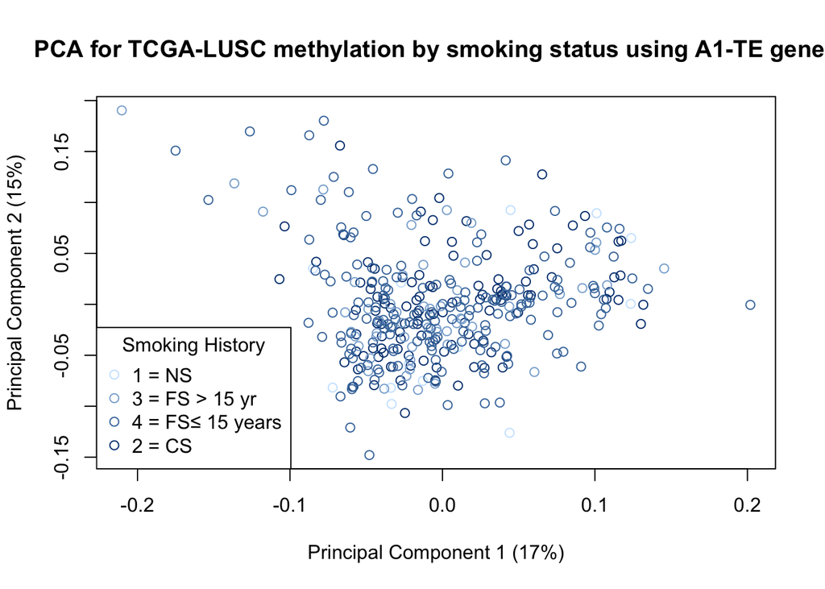

```r
library(limma)

## Setting up the dataframe

# Order the dataframe by smoking status
LUSC_methylation_hm450_tumor_sstat <- LUSC_methylation_hm450_tumor %>%
  select(clinical_data_smoking_history_sample_barcodes_methyl$bcr_patient_barcode)

# Filter to just A1-TE genes
LUSC_methylation_hm450_tumor_sstat_A1_TE <- LUSC_methylation_hm450_tumor_sstat %>%
  filter(rownames(.) %in% LUSC_A1_TE$Gene)


## Plot a PCA based on A1-TE genes, using color to represent smoking status

# Smoking status
smoking_status <- clinical_data_smoking_history_sample_barcodes_methyl$tobacco_smoking_history

# Only keep samples with status 1, 2, 3, or 4
valid_idx <- smoking_status %in% c(1, 2, 3, 4)
smoking_status_filtered <- smoking_status[valid_idx]

# Define custom order for color darkness
status_order <- c(1, 3, 4, 2)  # lightest to darkest

# Create color ramp
blues <- colorRampPalette(c("#cce6ff", "#004080"))(length(status_order))

# Create a named vector mapping statuses to colors
status_color_map <- setNames(blues, status_order)

# Assign colors to filtered samples
colors <- status_color_map[as.character(smoking_status_filtered)]

# Filter the data for plotting
filtered_data <- LUSC_methylation_hm450_tumor_sstat_A1_TE[, valid_idx]

# Plot MDS
plotMDS(filtered_data,
        gene.selection = "common",
        main = "PCA for TCGA-LUSC methylation by smoking status using A1-TE genes",
        col = colors,
        pch = 1)

# Add legend
legend("bottomleft",
       legend = paste(c("1 = NS",  "3 = FS > 15 yr", "4 = FS≤ 15 years", "2 = CS")),
       col = blues,
       pch = 1,
       title = "Smoking History")
```

```r
## Doesn't look like much of a trend happening here
```

## PCA of the LUSC methylation data using A1-TE-A2 genes and coloring by smoking status (filtering out 5 (FS of unspecified TSQ duration))

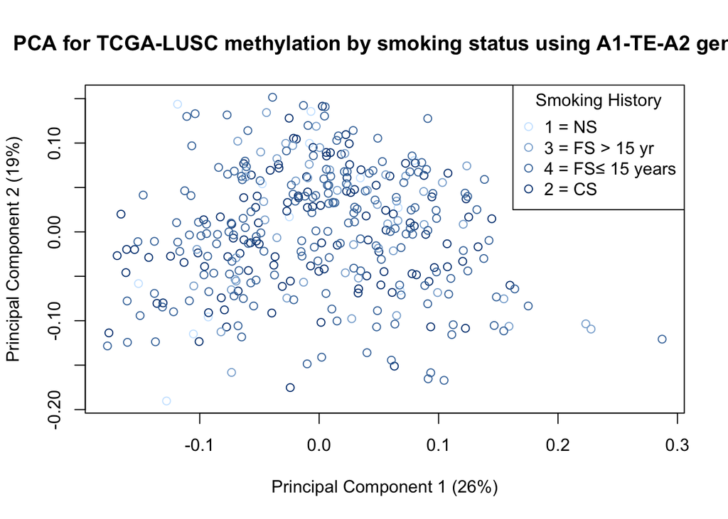

```r
library(limma)

## Setting up the dataframe

# Order the dataframe by smoking status
LUSC_methylation_hm450_tumor_sstat <- LUSC_methylation_hm450_tumor %>%
  select(clinical_data_smoking_history_sample_barcodes_methyl$bcr_patient_barcode)

# Filter to just A1-TE-A2 genes
LUSC_methylation_hm450_tumor_sstat_A1_TE_A2 <- LUSC_methylation_hm450_tumor_sstat %>%
  filter(rownames(.) %in% LUSC_A1_TE_A2$Gene)



## Plot a PCA based on A1-TE-A2 genes, using color to represent smoking status

# Smoking status
smoking_status <- clinical_data_smoking_history_sample_barcodes_methyl$tobacco_smoking_history

# Only keep samples with status 1, 2, 3, or 4
valid_idx <- smoking_status %in% c(1, 2, 3, 4)
smoking_status_filtered <- smoking_status[valid_idx]

# Define custom order for color darkness
status_order <- c(1, 3, 4, 2)  # lightest to darkest

# Create color ramp
blues <- colorRampPalette(c("#cce6ff", "#004080"))(length(status_order))

# Create a named vector mapping statuses to colors
status_color_map <- setNames(blues, status_order)

# Assign colors to filtered samples
colors <- status_color_map[as.character(smoking_status_filtered)]

# Filter the data for plotting
filtered_data <- LUSC_methylation_hm450_tumor_sstat_A1_TE_A2[, valid_idx]

# Plot MDS
plotMDS(filtered_data,
        gene.selection = "common",
        main = "PCA for TCGA-LUSC methylation by smoking status using A1-TE-A2 genes",
        col = colors,
        pch = 1)

# Add legend
legend("topright",
       legend = paste(c("1 = NS",  "3 = FS > 15 yr", "4 = FS≤ 15 years", "2 = CS")),
       col = blues,
       pch = 1,
       title = "Smoking History")
```

```r
## Doesn't look like much of a trend happening here
```

So far it doesn’t look like there is much of a trend happening here. I could also try hierarchical clustering, and maybe also try straight differential analysis and gene comparison instead. Also, maybe the thing that Carl DeBoer suggested which is looking at the “loads” of the genes in the PCA?

##4. Explore the statistical significance of overlapping genes and give a detailed report of the results and their implications.

For my foray into this see the script hypergeometric_confusion and the word document “SOS question”.